# Guía Modelos Lineales Generalizados

Curso Introducción al Análisis de datos con R para la acuicultura

Dr. José A. Gallardo y Dra. María Angélica Rueda.

Pontificia Universidad Católica de Valparaíso  
jose.gallardo@pucv.cl

31 July 2021

### MODELOS LINEALES GENERALIZADOS

Los modelos lineales generalizados extienden a los modelos lineales clásicos admitiendo distribuciones no normales para la variable respuesta y modelando funciones de la media.

Los MLG son, por tanto, una extensión de los modelos lineales que permiten utilizar distribuciones no normales de los errores (binomiales, Poisson, gamma, etc) y varianzas no constantes.

Características de un modelo lineal generalizado (MLG)

1). El MLG está conformado por componente aleatorio, componente sistemático y función de enlace.

2). La variable respuesta/residuos pueden tener distribución normal u otros tipos de distribuciones.

3). Existencia de observaciones correlacionadas.

4). Puede existir heterogeneidad de varianzas.

Incumplimiento de los supuestos:

1. Hay observaciones correlacionadas.
2. Los residuos se pueden o no distribuir **normalmente**.
3. Varianza no constante.

#### **Objetivos de aprendizaje**

Los objetivos de aprendizaje de esta guía son:

**1**. - Identificar componente aleatorio, componente sistemático y función de enlace.

**3**. - Ajustar modelos lineales generalizados.

**3**. - Realizar gráficas.

**4**. - Elaborar un reporte dinámico en formato pdf con **[Rmarkdown](https://rmarkdown.rstudio.com/)**.

## ESTUDIO DE CASO: BP

En este estudio de caso trabajaremos con un set de datos de 120 observaciones simuladas de black porgy.

La variable respuesta se denomina **Final_Biomass** y la variable predictora **Glucose**.

### **Ejercicio 1.** Elaborar y configurar Reporte en formato .Rmd

Elabore un documento .Rmd y configure su reporte para exportar en .pdf. Instale solo las liberías que utilice para el análisis de los datos.

```r
knitr::opts_chunk$set(echo = TRUE)
library(readxl)
library(ggplot2)
library(multcomp)
library(psych)
library(car)
library(readr)
library(lmtest)
library(boot)
```

Ejecute cada uno de los siguientes ejercicios en uno o más bloques de códigos diferentes. Sea ordenado y documente su reporte adecuadamente.

### **Ejercicio 2.** Exploratorio set de datos BP

Importe el set de datos **BP.xls** y realice un análisis exploratorio de datos.

Incluya:

**a).** Resumen estadístico de todas las variables.

```r
BP <- read_excel("BP.xls")
summary(BP)
```

```
##        ID         Final_Biomass      Glucose
##  Min.   :  1.00   Min.   :28120   Min.   :38.00
##  1st Qu.: 30.75   1st Qu.:28723   1st Qu.:57.00
##  Median : 60.50   Median :28985   Median :63.00
##  Mean   : 60.50   Mean   :28999   Mean   :63.24
##  3rd Qu.: 90.25   3rd Qu.:29258   3rd Qu.:70.00
##  Max.   :120.00   Max.   :30152   Max.   :85.00
```

**b).** Ajuste un modelo lineal general donde la variable Final_Biomass es la variable respuesta y la variable Glucose es la variable predictora. Use la función **lm()** y haga el **summary()** del modelo.

```r
modelo1 <- lm(Final_Biomass~Glucose, data = BP)
summary(modelo1)
```

```
##
## Call:
## lm(formula = Final_Biomass ~ Glucose, data = BP)
##
## Residuals:
##     Min      1Q  Median      3Q     Max
## -808.15 -263.61  -34.03  255.38 1163.91
##
## Coefficients:
##              Estimate Std. Error t value Pr(>|t|)
## (Intercept) 28683.411    249.317 115.048   <2e-16 ***
## Glucose         4.995      3.896   1.282    0.202
## ---
## Signif. codes:  0 '***' 0.001 '**' 0.01 '*' 0.05 '.' 0.1 ' ' 1
##
## Residual standard error: 417.9 on 118 degrees of freedom
## Multiple R-squared:  0.01374,    Adjusted R-squared:  0.00538
## F-statistic: 1.644 on 1 and 118 DF,  p-value: 0.2023
```

**c).** Realice el grafico de puntos con la función plot() de Glucose y Final_Biomass. Realice la recta ajustada del modelo con la función abline(coef(modelo1)).

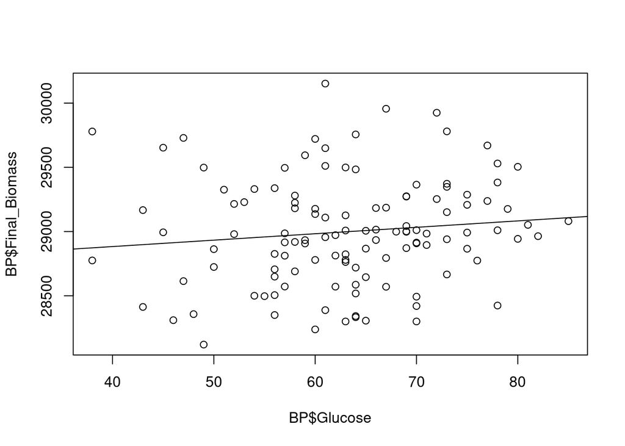

```r
plot(BP$Glucose, BP$Final_Biomass)
abline(coef(modelo1))
```

**d).** Histograma de la variable respuesta **Final_Biomass**.

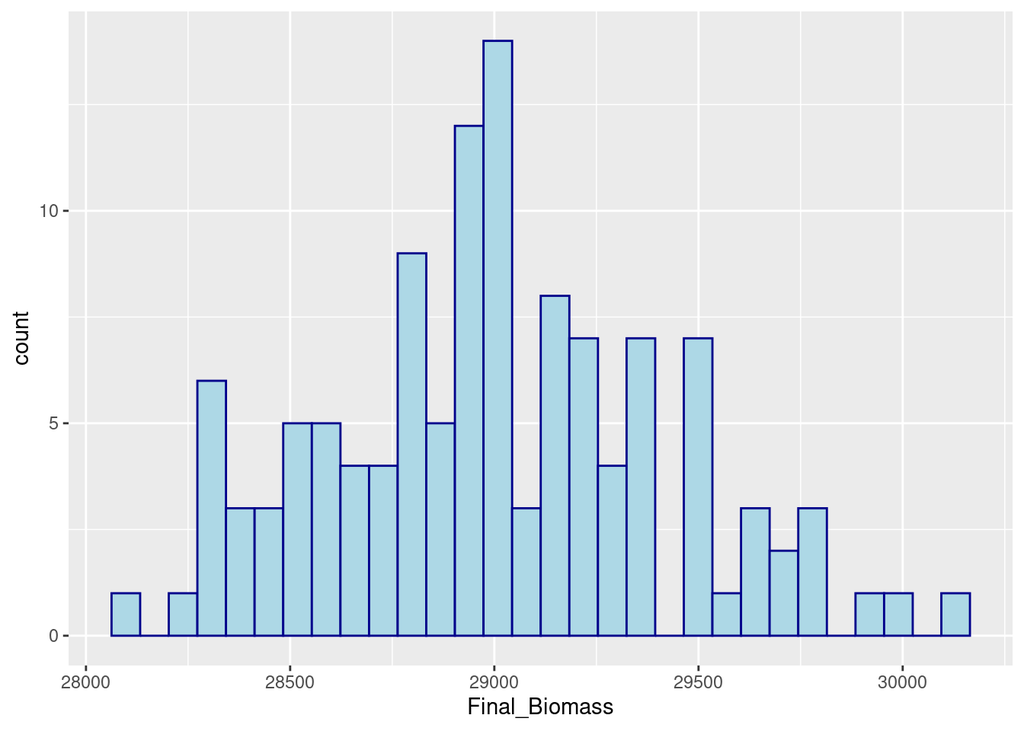

```r
ggplot(BP, aes(x=Final_Biomass))+
  geom_histogram(color="darkblue", fill="lightblue")
```

### **Ejercicio 3.** Modelo lineal generalizado (normal)

**a).** Ajuste un modelo lineal generalizado donde la variable Final_Biomass es la variable respuesta y la variable Glucose es la variable predictora. Use la función glm(), considere el parámetro family= gaussian(link=“identity”). Luego, realice el summary() del modelo.

```r
modelo2 <- glm(Final_Biomass~Glucose,family= gaussian(link="identity"), data = BP)

summary(modelo2)
```

```
##
## Call:
## glm(formula = Final_Biomass ~ Glucose, family = gaussian(link = "identity"),
##     data = BP)
##
## Deviance Residuals:
##     Min       1Q   Median       3Q      Max
## -808.15  -263.61   -34.03   255.38  1163.91
##
## Coefficients:
##              Estimate Std. Error t value Pr(>|t|)
## (Intercept) 28683.411    249.317 115.048   <2e-16 ***
## Glucose         4.995      3.896   1.282    0.202
## ---
## Signif. codes:  0 '***' 0.001 '**' 0.01 '*' 0.05 '.' 0.1 ' ' 1
##
## (Dispersion parameter for gaussian family taken to be 174635)
##
##     Null deviance: 20893964  on 119  degrees of freedom
## Residual deviance: 20606926  on 118  degrees of freedom
## AIC: 1793
##
## Number of Fisher Scoring iterations: 2
```

**b).** Pruebe es supuesto de normalidad sobre los residuos de deviance de forma gráfica.

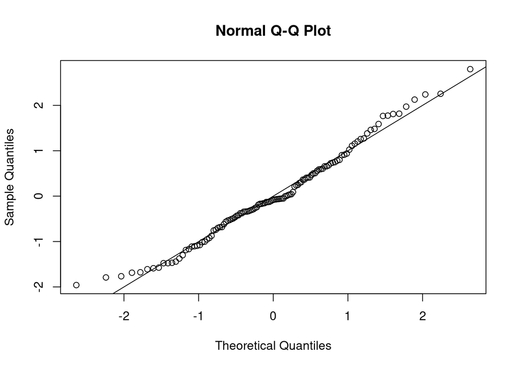

```r
qqnorm(glm.diag(modelo2)$rd)
abline(0,1)
```

**c).** Pruebe es supuesto de normalidad sobre los residuos de deviance con la prueba de shapiro test.

```r
shapiro.test(glm.diag(modelo2)$rd)
```

```
##
##  Shapiro-Wilk normality test
##
## data:  glm.diag(modelo2)$rd
## W = 0.98278, p-value = 0.1289
```

**d).** Obtenga la deviance nula y la deviance para obtener el coeficiente de determinación del modelo de regresión lineal con la información del modelo2.

```r
modelo2$null.deviance
```

```
## [1] 20893964
```

```r
modelo2$deviance
```

```
## [1] 20606926
```

```r
R2 <- (modelo2$null.deviance-modelo2$deviance)/modelo2$null.deviance
R2
```

```
## [1] 0.01373786
```

### **Ejercicio 4.** Comparación y selección de modelos

**a).** Comparar los modelos 1 y 2 con el criterio de información de Akaike usando la función anova().

```r
anova(modelo1, modelo2)
```

```
## Analysis of Variance Table
##
## Model 1: Final_Biomass ~ Glucose
## Model 2: Final_Biomass ~ Glucose
##   Res.Df      RSS Df Sum of Sq F Pr(>F)
## 1    118 20606926
## 2    118 20606926  0         0
```

¿Qué observó al pedir el anova de los dos modelos ajustados?

### **Ejercicio 5.** Modelo lineal generalizado bernoulli (Datos_Cangrejos)

El set de **Datos_cangrejos.xslx** son 173 datos de cangrejos herradura hembras de la librería de R (glmbb) llamada *crabs*. Donde se les midieron 6 variables. Ver descripción de dataset en https://cran.r-project.org/web/packages/glmbb/glmbb.pdf

**a).** Resumen estadístico de todas las variables.

```r
Datos_cangrejos <- read_excel("Datos_cangrejos.xlsx")
summary(Datos_cangrejos)
```

```
##     color              spine               width          satell
##  Length:173         Length:173         Min.   :21.0   Min.   : 0.000
##  Class :character   Class :character   1st Qu.:24.9   1st Qu.: 0.000
##  Mode  :character   Mode  :character   Median :26.1   Median : 2.000
##                                        Mean   :26.3   Mean   : 2.919
##                                        3rd Qu.:27.7   3rd Qu.: 5.000
##                                        Max.   :33.5   Max.   :15.000
##      weight           y
##  Min.   :1200   Min.   :0.0000
##  1st Qu.:2000   1st Qu.:0.0000
##  Median :2350   Median :1.0000
##  Mean   :2437   Mean   :0.6416
##  3rd Qu.:2850   3rd Qu.:1.0000
##  Max.   :5200   Max.   :1.0000
```

**b).** Ajuste un modelo lineal generalizado nulo donde la variable **y** es la variable respuesta y no hay variable predictora en ese caso colocar y en función de 1. Use la función glm(), considere el parámetro family= binomial. Luego, realice el summary() del modelo.

```r
modelo3 <- glm(y ~ 1, family= binomial, data = Datos_cangrejos)
summary(modelo3)
```

```
##
## Call:
## glm(formula = y ~ 1, family = binomial, data = Datos_cangrejos)
##
## Deviance Residuals:
##     Min       1Q   Median       3Q      Max
## -1.4326  -1.4326   0.9421   0.9421   0.9421
##
## Coefficients:
##             Estimate Std. Error z value Pr(>|z|)
## (Intercept)   0.5824     0.1585   3.673 0.000239 ***
## ---
## Signif. codes:  0 '***' 0.001 '**' 0.01 '*' 0.05 '.' 0.1 ' ' 1
##
## (Dispersion parameter for binomial family taken to be 1)
##
##     Null deviance: 225.76  on 172  degrees of freedom
## Residual deviance: 225.76  on 172  degrees of freedom
## AIC: 227.76
##
## Number of Fisher Scoring iterations: 4
```

**c).** Ajuste un modelo lineal generalizado donde la variable y es la variable respuesta y la variable width es la variable predictora. Use la función glm(), considere el parámetro family= binomial. Luego, realice el summary() del modelo.

```r
modelo4 <- glm(y~width, family= binomial, data = Datos_cangrejos)
summary(modelo4)
```

```
##
## Call:
## glm(formula = y ~ width, family = binomial, data = Datos_cangrejos)
##
## Deviance Residuals:
##     Min       1Q   Median       3Q      Max
## -2.0281  -1.0458   0.5480   0.9066   1.6942
##
## Coefficients:
##             Estimate Std. Error z value Pr(>|z|)
## (Intercept) -12.3508     2.6287  -4.698 2.62e-06 ***
## width         0.4972     0.1017   4.887 1.02e-06 ***
## ---
## Signif. codes:  0 '***' 0.001 '**' 0.01 '*' 0.05 '.' 0.1 ' ' 1
##
## (Dispersion parameter for binomial family taken to be 1)
##
##     Null deviance: 225.76  on 172  degrees of freedom
## Residual deviance: 194.45  on 171  degrees of freedom
## AIC: 198.45
##
## Number of Fisher Scoring iterations: 4
```

**d).** Comparar los modelos 3 y 4 con el criterio de información de Akaike usando la función anova().

```r
anova(modelo3, modelo4)
```

```
## Analysis of Deviance Table
##
## Model 1: y ~ 1
## Model 2: y ~ width
##   Resid. Df Resid. Dev Df Deviance
## 1       172     225.76
## 2       171     194.45  1   31.306
```

**e).** Realice el exponencial de los coeficientes del modelo 4.

```r
exp(modelo4$coefficients)
```

```
##  (Intercept)        width
## 4.326214e-06 1.644162e+00
```

**f).** ¿Cuál es la chance de tener éxito? Use el resultado del ítem e) para contestar esta pregunta.

```r
# La chance de tener éxito se incrementa 64.41% por cada unidad de aumento en la variable width.
```